# Report of Power Analysis

Cooper

12/12/2022

## 1 Background

This report provides a summary of power analysis in GAPCare I Dataset. We used different methods and parameters to calculate the sample sizes.

### 1.1 Population

The first thing needs to be considered is the population. We considered two populations. The first one is the whole population (55 patients in usual-care group and 55 in intervention group). Another two are patients with dementia and patients without dementia. The total sample size will be 500. If we consider the two subgroups of dementia and non-dementia, the sample size will be $500*0.15=75$ for dementia and $500*0.85=425$ for non-dementia. When we consider three populations together, we need to use Bonferroni correlation if powers calculated from p-values.

### 1.2 Methods

We considered three methods to calculate powers. The first one is based on theoretical formulas (Negative Binomial Regression Version). The second one is based on 1000 simulations. The third one is based on 1000 bootstraps.

## 2 Preliminary R Code

In this section, we will show the r codes for loading and installing r packages, importing dataset, and the histogram of fall-related ED visits from GAPCare I Dataset.

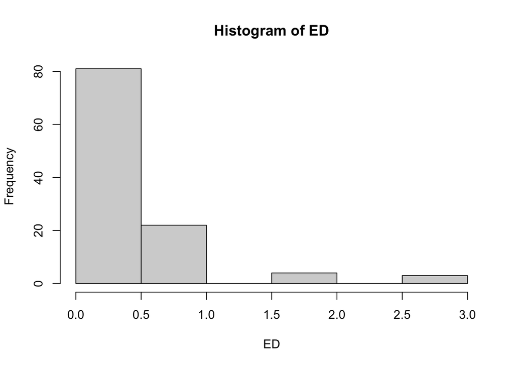

```r
##Import Library
library(dplyr)
library(MASS)

## Impoort data set
setwd('/Users/dhyscuduke/Desktop')
DATA = read.csv('/Users/dhyscuduke/Desktop/GAPcare_I_cleaned.csv')

##Fall related ED visits
ED <- na.omit(DATA$Final_ED)

##Check the histogram of fall-related ED visits
hist(ED)
```

## 3 Whole Population

In this section, we calculated powers based on the whole population

### 3.1 Theoretical Formula Using GAPCare I Dataset

#### 3.1.1 Foundation of Mathematical Theory

Since the fall-related ED visits follow the negative binomial distribution. We will use the negative binomial regression model based sample size calculation formula to do power analysis. The formula of sample size calculation based on negative binomial regression is:
$$\sqrt{N}=\frac{\left(Z_{1-\alpha/2}+Z_{1-\beta}\right)\sqrt{\frac{1}{Q_1}\left(\frac{1}{\mu_1}+\frac{1}{k_1}\right)+\frac{1}{Q_0}\left(\frac{1}{\mu_0}+\frac{1}{k_0}\right)}}{log\left(\mu_0\right)-log\left(\mu_1\right)}$$
In this formula, $N$ is the sample size for whole population which is 500. Parameters $\alpha$ and $\beta$ are type I error and type II error. Parameters $\mu_0$ and $\mu_1$ are the means of fall-related ED visits in usual-care and intervention groups. Parameters $Q_1=N_1/N$ and $Q_0=N_0/N$ are the proportions of each group. Here the two groups have the same sample size 250. Therefore $Q_1=Q_0=0.5$. Finally, the parameter $k_1=k_0=k$ will be the $\theta$, the dispersion of the negative binomial regression model.

The negative binomial regression model will be based on fall-related ED visits Y and intervention X. If we set the total mean is $\mu$ and dispersion as $\theta$. The regression model is:
$$Y \sim X；Y \sim Negbin(\mu, \theta)$$

#### 3.1.2 Power Calculation

Below is the r code to calculate the power based on negative binomial regression sample size formula:

```r
#Negative Binomial Regression
Inter <- na.omit(DATA$Intervention)
nbGLM <- glm.nb(ED ~ Inter, data=DATA)

#Power Calculation
Disper <- nbGLM$theta #The parameter we will use in formula (k)
inter1 <- DATA %>% filter(Intervention == "0")
inter2 <- DATA %>% filter(Intervention == "1")
mu1 <- mean(inter1$Final_ED.1)
mu2 <- mean(inter2$Final_ED.1)
step1 <- ((log(mu1)-log(mu2))*sqrt(500))/(sqrt(2*(2/Disper+1/mu1+1/mu2)))
power1 <- pnorm(step1-qnorm(0.975))
```

Th outcome of the power is 84%.

### 3.2 Theoretical Formula Using 30% Efficacy

Everything in the previous formulas are not change. The only change here is that instead of using real $\mu_1$, we use the 30% efficacy decrease from $\mu_0$ to represent $\mu_1$. The r code for this method is shown below:

```r
#Power Calculation by using 30% efficacy
Disper <- nbGLM$theta #The parameter we will use in formula (k)
inter1 <- DATA %>% filter(Intervention == "0")
inter2 <- DATA %>% filter(Intervention == "1")
mu1 <- mean(inter1$Final_ED.1)
mu2 <- 0.7*mu1
step1 <- ((log(mu1)-log(mu2))*sqrt(500))/(sqrt(2*(2/Disper+1/mu1+1/mu2)))
power1 <- pnorm(step1-qnorm(0.975))
```

The outcome of the power is 57% if we use 30% efficacy decrease which is smaller a lot than the 84% power. The reason is that the efficacy decrease could be achieve as 40% if using GAPCare I Data.

### 3.3 Simulation Methods Using GAPCare I Dataset

#### 3.3.1 Foundation of Mathematical Theory

In simulation based method, we will use the original negative binomial distribution to generate more data which also follow negative binomial distribution. The sample size of the generated data is 500. Since we need to consider both usual-care group and intervention group, we decided to generate each group separately.
$$Simu\_Usual \sim Negbin(\mu_0, \theta)$$
$$Simu\_Intervention \sim Negbin(\mu_1,
\theta)$$
The sample size in each group is 250. After generating the two groups data, we generate 250 0s and 250 1s. The we use the new generated data to do negative binomial regression again.
$$Simu\_Y \sim Simu\_X$$
Then, we could get the p-value of the parameter of intervention variable. If the p-value is smaller than 0.05. we could say the alternative hypothesis is right and we accept. The probability of p-values smaller than 0.05 is the estimated power we want. In order to avoid power equal to 0, the estimated power should be:
$$Power =
\frac{P_{simu}+1}{N_{s}+1}$$
Here $P_{simu}$ is the number of p-values smaller than 0.05 amd $N_s$ is the total number of simulations. The number of simulations is 1000.

#### 3.3.2 Power Calculation

Here is the r code for the power calculation based on simulation method by GARCare I Data:

```r
j <- 0 #Calculate the number of p-values smaller than 0.05
for (i in 1:1000){
  Simuy1 <- rnbinom(n=250, mu=mu1, size=Disper) #Simulate Control Group Dataset
  Simuy2 <- rnbinom(n=250, mu=mu2, size=Disper) #Simulate Case Group Dataset
  Simuy <- c(Simuy1, Simuy2) #Whole simulated Dataset
  Simux1 <- rep(0:0,250)
  Simux2 <- rep(1:1,250)
  Simux <- c(Simux1, Simux2) #Whole simulated intervention indicators
  nbGLM_2 <- glm.nb(Simuy ~ Simux)
  p_value <- summary(nbGLM_2)$coefficients[2,4]
  if (p_value < 0.05){
    j <- j+1
  }
}
power2 <- (j+1)/1001
```

The estimated power is around 86%.

### 3.4 Simulation Based Method Using 30% efficacy

Everything in the previous section are not change. The only change here is that instead of using real $\mu_1$, we used the 30% efficacy decrease from $\mu_0$ to present $\mu_1$. The r code for this method is shown below:

```r
j <- 0 #Calculate the number of p-values smaller than 0.05
for (i in 1:1000){
  Simuy1 <- rnbinom(n=250, mu=mu1, size=Disper) #Simulate Control Group Dataset
  Simuy2 <- rnbinom(n=250, mu=0.7*mu1, size=Disper) #Simulate Case Group Dataset
  Simuy <- c(Simuy1, Simuy2) #Whole simulated Dataset
  Simux1 <- rep(0:0,250)
  Simux2 <- rep(1:1,250)
  Simux <- c(Simux1, Simux2) #Whole simulated intervention indicators
  nbGLM_2 <- glm.nb(Simuy ~ Simux)
  p_value <- summary(nbGLM_2)$coefficients[2,4]
  if (p_value < 0.05){
    j <- j+1
  }
}
power2 <- (j+1)/1001
```

The outcome of the estimated power is around 57% if we use 30% efficacy decrease which is smaller a lot than the 86% power. The reason is the same that the efficacy decrease could be achieve as 40% if using GAPCare I Data.

### 3.5 Bootstrap Based Method

#### 3.5.1 Theoretical Bases of Bootstrap Method

Bootstrap method is very similar to the simulation method. Both of them generate the 500 new data from the original 110 dataset. However, simulation method generates the new dataset through negative binomial distribution and bootstrap generates by extracting and putting back to achieve 500 dataset. Therefore, simulation method generates new data and bootstrap generates repeated original data.

In bootstrap method, we could consider different covariates. The covariates ajusted are sex, age, number of falls in previous 3 months, injured during index fall, hospital site, and previous assistive equipment use.We created an empty matrix and each line maintains the chosen fall-related ED visits, intervention, and all covariates. The matrix has 500 rows. After that, we could use the data in the matrix to do negative binomial regression between fall-related ED visits and intervention ajusted with covariates. One negative binomial regression model will generate one p-value. Repeat the whole process 1000 times and the probability of p-values smaller than 0.05 is the estimated power. To calculate the estimated power, use the formula below:
$$Power =
\frac{P_{bootstrp}+1}{N_{s}+1}$$

#### 3.5.2 Power Calculation

Here is the r code for power calculation based on bootstrap:

```r
#Sample Size Calculation in Bootstrap
New_DATA <- data.frame(DATA$Final_ED.1, DATA$Intervention, DATA$Total_Age, DATA$Total_Sex,
                       DATA$Total_no_falls, DATA$Total_cci, DATA$Total_bi_score,
                       DATA$Total_injuries, DATA$Total_Hospital, DATA$Total_equ)
New_DATA1 <- New_DATA %>% filter(DATA.Intervention == "0")
New_DATA2 <- New_DATA %>% filter(DATA.Intervention == "1")
New_DATA <- rbind(New_DATA1, New_DATA2)

m1 <- 0
for (i1 in 1:1000){
  Bootstrap_DATA <- as.data.frame(matrix(nrow = 500, ncol = 10))
  for (j1 in 1:500){
    k <- sample(1:110,1)
    Bootstrap_DATA[j1,] = New_DATA[k,]
  }
  nbGLM_3 <- glm.nb(V1 ~ V2 + V3 + V4 + V5
                    +  V8 + V9
                    + V10, data = Bootstrap_DATA)
  p_value <- summary(nbGLM_3)$coefficients[2,4]
  if (p_value < 0.05){
    m1 <- m1 + 1
  }
}
power3 <- (1+m1)/1000
```

The outcome of the power is around 94%.

## 4 Three Subgroups

In this section, we consider three populations together. They are the whole population, the population with dementia, and the population without the dementia. In original GAPCare I Dataset, there are 16 patients with dem and 91 patients without dem. Therefore, we consider 15% patient in the sample size will have dem and 85% will not have. The total sample size is 500, so the sample size for dem group will be 75 and for non-dem group will be 425.

```r
# Import data set
setwd('/Users/dhyscuduke/Desktop')
DATA = read.csv('/Users/dhyscuduke/Desktop/GAPcare_I_cleaned2.csv')

#Clean Data Based on Dem
DATA1 <- DATA %>% filter(Dem == "1") #Patients with Dem
DATA2 <- DATA %>% filter(Dem == "0") #Patients with No Dem
```

Since we consider three populations together and each patient appeared twice in two populations, we need to use Bonferroni correlation when the methods involving p-values (Simulation and Bootstrap). That means:
$$P-value < \frac{0.05}{3}$$
In this section, we will consider two parameters as well, GAPCare I Data and 30% efficacy decrease.

### 4.1 Theoretical Formula Using GAPCare I Dataset

#### 4.1.1 Foundation of Mathematical Theory

The formula of how to calculate sample size in negative binomial regression model is same as the previous one. So we will not introduce it again. The outcome of the power for whole population will not change as well. However, for data with Dem or non-Dem, we need to consider them seperately. For each subgroups, we need to set up a negative binomial regression model to calculate dispersion parameter $\theta$.
$$Y_1
\sim X_1, Y_1 \sim Negbin(\mu_{Dem}, \theta_1)$$
$$Y_2 \sim X_2, Y_2 \sim Negbin(\mu_{non-Dem},
\theta_2)$$
Then, in each subgroup, we need to consider different sample size, proportions with intervention or not, and dispersion to calculate two powers.

#### 4.1.1 Power Calculation

The r code for the power calculation in subgroup with Dem:

```r
#Negative Binomial Regression with Dem
Inter1 <- na.omit(DATA1$Intervention)
ED1 <- na.omit(DATA1$Final_ED.1)
nbGLM1 <- glm.nb(DATA1$Final_ED.1 ~ DATA1$Intervention.1)
Disper1 <- nbGLM1$theta

#Sample Size Calculation with Dem
inter11 <- DATA1 %>% filter(Intervention == "0")
inter21 <- DATA1 %>% filter(Intervention == "1")
mu11 <- mean(inter11$Final_ED.1)
mu21 <- mean(inter21$Final_ED.1)
step11 <- -((log(mu11)-log(mu21))*sqrt(75))/(sqrt((16/6)*(1/mu11+1/Disper1)+(16/10)*(1/mu21+1/Disper1)))
power11 <- pnorm(step11-qnorm(0.975))
```

The outcome for the power is 58%.

The r code for the power calculation in subgroup without Dem:

```r
#Negative Binomial Regression without Dem
Inter2 <- na.omit(DATA2$Intervention)
ED2 <- na.omit(DATA2$Final_ED.1)
nbGLM2 <- glm.nb(DATA2$Final_ED.1 ~ DATA2$Intervention.1)
Disper2 <- nbGLM2$theta

#Sample Size Calculation without Dem
inter12 <- DATA2 %>% filter(Intervention == "0")
inter22 <- DATA2 %>% filter(Intervention == "1")
mu12 <- mean(inter12$Final_ED.1)
mu22 <- mean(inter22$Final_ED.1)
step12 <- ((log(mu12)-log(mu22))*sqrt(425))/(sqrt((91/47)*(1/mu12+1/Disper2)+(91/44)*(1/mu22+1/Disper2)))
power12 <- pnorm(step12-qnorm(0.975))
```

The outcome for the power is 95%. In general case, the power for non-Dem should not be higher than the power for whole population. The reason why this happened I think is that the non-Dem has smaller dispersion than the whole population.

### 4.2 Theoretical Formula Using 30% efficacy

#### 4.2.1 Power Calculation

The r code for the power calculation in subgroup with Dem, 30% efficacy decrease:

```r
#Sample Size Calculation with Dem 30% efficacy
inter11 <- DATA1 %>% filter(Intervention == "0")
inter21 <- DATA1 %>% filter(Intervention == "1")
mu11 <- mean(inter11$Final_ED.1)
mu21 <- 0.7*mu11
step11 <- ((log(mu11)-log(mu21))*sqrt(75))/(sqrt((16/6)*(1/mu11+1/Disper1)+(16/10)*(1/mu21+1/Disper1)))
power11 <- pnorm(step11-qnorm(0.975))
```

The outcome for the power is 8%.

The r code for the power calculation in subgroup without Dem, 30% efficacy decrease:

```r
#Sample Size Calculation without Dem 30% efficacy
inter12 <- DATA2 %>% filter(Intervention == "0")
inter22 <- DATA2 %>% filter(Intervention == "1")
mu12 <- mean(inter12$Final_ED.1)
mu22 <- 0.7*mu12
step12 <- ((log(mu12)-log(mu22))*sqrt(425))/(sqrt((91/47)*(1/mu12+1/Disper2)+(91/44)*(1/mu22+1/Disper2)))
power12 <- pnorm(step12-qnorm(0.975))
```

The outcome for the power is 49%.

### 4.3 Simulation Methods Using GAPCare I Dataset

In this section, we need to use p-values to estimate power. Therefore, Bonferroni correlation should be used here. On the other hand, the sample sizes used for simulations in the two subgroups are 75 and 425 and the two simulations are based on the their own negative binomial regression model with different dispersions. Another thing needs to be noticed is that in whole population, the simulation is completed in two different 250 sample groups. However, in the two subgroups, the simulation is completed in 28 and 47 with Dem, and 220 and 205 without Dem. The reason in the whole population, the sample sizes for two groups with intervention or not are 55 and 55. But in the two subgroups are 6 amd 10, and 47 and 44. Therefore, the proportions of each small group should follow their origianl ones before simulation.

#### 4.3.1 Power Calculation

The r code for the power calculation for the whole group by simulation is:

```r
#Sample Size Calculation in Simulation

#Whole Population
j <- 0
for (i in 1:1000){
  Simuy1 <- rnbinom(n=250, mu=mu1, size=Disper) #Simulate Control Group Dataset
  Simuy2 <- rnbinom(n=250, mu=mu2, size=Disper) #Simulate Case Group Dataset
  Simuy <- c(Simuy1, Simuy2) #Whole simulated Dataset
  Simux1 <- rep(0:0,250)
  Simux2 <- rep(1:1,250)
  Simux <- c(Simux1, Simux2) #Whole simulated intervention indicators
  nbGLM_2 <- glm.nb(Simuy ~ Simux)
  p_value <- summary(nbGLM_2)$coefficients[2,4]
  #Bonferroni correction - p = 0.05/3
  if (p_value < 0.05/3){
    j <- j+1
  }
}
power2 <- (j+1)/1001
```

The outcome of the power is 73%.

The r code for the power calculation for the Dem group by simulation is:

```r
#Sample Size Calculation in Simulation

#Dem
j <- 0
for (i in 1:1000){
  Simuy11 <- rnbinom(n=28, mu=mu11, size=Disper1) #Simulate Control Group Dataset
  Simuy21 <- rnbinom(n=47, mu=mu21, size=Disper1) #Simulate Case Group Dataset
  Simuy_1 <- c(Simuy11, Simuy21) #Whole simulated Dataset
  Simux11 <- rep(0:0,28)
  Simux21 <- rep(1:1,47)
  Simux_1 <- c(Simux11, Simux21) #Whole simulated intervention indicators
  nbGLM_11 <- glm.nb(Simuy_1 ~ Simux_1)
  p_value <- summary(nbGLM_11)$coefficients[2,4]
  if (p_value < 0.05/3){
    j <- j+1
  }
}
power21 <- (j+1)/1001
```

The outcome of the power is 36%.

The r code for the power calculation for the Non-Dem group by simulation is:

```r
#No Dem
j <- 0
for (i in 1:1000){
  Simuy12 <- rnbinom(n=220, mu=mu12, size=Disper2)
  Simuy22 <- rnbinom(n=205, mu=mu22, size=Disper2)
  Simuy_2 <- c(Simuy12, Simuy22)
  Simux12 <- rep(0:0,220)
  Simux22 <- rep(1:1,205)
  Simux_2 <- c(Simux12, Simux22)
  nbGLM_12 <- glm.nb(Simuy_2 ~ Simux_2)
  p_value <- summary(nbGLM_12)$coefficients[2,4]
  if (p_value < 0.05/3){
    j <- j+1
  }
}
power22 <- (j+1)/1001
```

The outcome of the power is 92%.

### 4.4 Simulation Methods Using 30% efficacy

The r code for the power calculation for the whole group by simulation is:

```r
#Whole Population 30% Efficacy
j <- 0
for (i in 1:1000){
  Simuy1 <- rnbinom(n=250, mu=mu1, size=Disper) #Simulate Control Group Dataset
  Simuy2 <- rnbinom(n=250, mu=mu1*0.7, size=Disper) #Simulate Case Group Dataset
  Simuy <- c(Simuy1, Simuy2) #Whole simulated Dataset
  Simux1 <- rep(0:0,250)
  Simux2 <- rep(1:1,250)
  Simux <- c(Simux1, Simux2) #Whole simulated intervention indicators
  nbGLM_2 <- glm.nb(Simuy ~ Simux)
  p_value <- summary(nbGLM_2)$coefficients[2,4]
  #Bonferroni correction - p = 0.05/3
  if (p_value < 0.05/3){
    j <- j+1
  }
}
power2 <- (j+1)/1001
```

The outcome of the power is 42%.

The r code for the power calculation for the Dem group by simulation is:

```r
#Dem 30% Efficacy
j <- 0
for (i in 1:1000){
  Simuy11 <- rnbinom(n=28, mu=mu11, size=Disper1) #Simulate Control Group Dataset
  Simuy21 <- rnbinom(n=47, mu=mu11*0.7, size=Disper1) #Simulate Case Group Dataset
  Simuy_1 <- c(Simuy11, Simuy21) #Whole simulated Dataset
  Simux11 <- rep(0:0,28)
  Simux21 <- rep(1:1,47)
  Simux_1 <- c(Simux11, Simux21) #Whole simulated intervention indicators
  nbGLM_11 <- glm.nb(Simuy_1 ~ Simux_1)
  p_value <- summary(nbGLM_11)$coefficients[2,4]
  if (p_value < 0.05/3){
    j <- j+1
  }
}
power21 <- (j+1)/1001
```

The outcome of the power is 2.2%.

The r code for the power calculation for the Non-Dem group by simulation is:

```r
#Dem 30% Efficacy
#Non-Dem 30% Efficacy
j <- 0
for (i in 1:1000){
  Simuy12 <- rnbinom(n=220, mu=mu12, size=Disper2)
  Simuy22 <- rnbinom(n=205, mu=mu12*0.7, size=Disper2)
  Simuy_2 <- c(Simuy12, Simuy22)
  Simux12 <- rep(0:0,220)
  Simux22 <- rep(1:1,205)
  Simux_2 <- c(Simux12, Simux22)
  nbGLM_12 <- glm.nb(Simuy_2 ~ Simux_2)
  p_value <- summary(nbGLM_12)$coefficients[2,4]
  if (p_value < 0.05/3){
    j <- j+1
  }
}
power22 <- (j+1)/1001
```

The outcome of the power is 32%.

### 4.5 Bootstrap Based Method

#### 4.5.1 Theoretical Bases of Bootstrap Method

The main thoughts for bootstrap here is similar to the previous one. Therefore, it will not be introduced again. There are two points need to be noticed. The first point is that we still used Bonferroni correlation here so that p-values should be smaller 0.05/3 in order to be significant. Another point is that in the two subgroups, the times of bootstrap are 75 and 425, not 500.

#### 4.5.2 Power Calculation

The r code for power calculation in whole population based on Bootstrap:

```r
#Sample Size Calculation in Bootstrap
New_DATA <- data.frame(DATA$Final_ED.1, DATA$Intervention, DATA$Total_Age, DATA$Total_Sex,
                       DATA$Total_no_falls, DATA$Total_cci, DATA$Total_bi_score,
                       DATA$Total_injuries, DATA$Total_Hospital, DATA$Total_equ)
New_DATA1 <- New_DATA %>% filter(DATA.Intervention == "0")
New_DATA2 <- New_DATA %>% filter(DATA.Intervention == "1")
New_DATA <- rbind(New_DATA1, New_DATA2)

#For Whole Population
m1 <- 0
for (i1 in 1:1000){
  Bootstrap_DATA <- as.data.frame(matrix(nrow = 500, ncol = 10))
  for (j1 in 1:500){
    k <- sample(1:110,1)
    Bootstrap_DATA[j1,] = New_DATA[k,]
  }
  nbGLM_3 <- glm.nb(V1 ~ V2 + V3 + V4 + V5
                    +  V8 + V9
                    + V10, data = Bootstrap_DATA)
  p_value <- summary(nbGLM_3)$coefficients[2,4]
  if (p_value < 0.05/3){
    m1 <- m1 + 1
  }
}
power3 <- (1+m1)/1001
```

The outcome of the power is 87%.

The r code for power calculation in Dem population based on Bootstrap:

```r
#Sample Size Calculation in Bootstrap For Dem
New_DATA_1 <- data.frame(DATA1$Final_ED.1, DATA1$Intervention, DATA1$Total_Age, DATA1$Total_Sex,
                       DATA1$Total_no_falls, DATA1$Total_cci, DATA1$Total_bi_score,
                       DATA1$Total_injuries, DATA1$Total_Hospital, DATA1$Total_equ)
New_DATA11 <- New_DATA_1 %>% filter(DATA1.Intervention == "0")
New_DATA21 <- New_DATA_1 %>% filter(DATA1.Intervention == "1")
New_DATA_1 <- rbind(New_DATA11, New_DATA21)

m1 <- 0
for (i1 in 1:1000){
  Bootstrap_DATA_1 <- as.data.frame(matrix(nrow = 75, ncol = 10))
  for (j1 in 1:75){
    k <- sample(1:16,1)
    Bootstrap_DATA_1[j1,] = New_DATA_1[k,]
  }
  nbGLM_3_1 <- glm.nb(V1 ~ V2 + V3 + V4 + V5
                    +  V8 + V9
                    + V10, data = Bootstrap_DATA_1)
  p_value <- summary(nbGLM_3_1)$coefficients[2,4]
  if (p_value < 0.05/3){
    m1 <- m1 + 1
  }
}
power3_1 <- (1+m1)/1001
```

The outcome of the power is 1.1%.

The r code for power calculation in non-Dem population based on Bootstrap:

```r
#Sample Size Calculation in Bootstrap without dem
New_DATA_2 <- data.frame(DATA2$Final_ED.1, DATA2$Intervention, DATA2$Total_Age, DATA2$Total_Sex,
                         DATA2$Total_no_falls, DATA2$Total_cci, DATA2$Total_bi_score,
                         DATA2$Total_injuries, DATA2$Total_Hospital, DATA2$Total_equ)
New_DATA12 <- New_DATA_2 %>% filter(DATA2.Intervention == "0")
New_DATA22 <- New_DATA_2 %>% filter(DATA2.Intervention == "1")
New_DATA_2 <- rbind(New_DATA12, New_DATA22)

m1 <- 0
for (i1 in 1:1000){
  Bootstrap_DATA_2 <- as.data.frame(matrix(nrow = 425, ncol = 10))
  for (j1 in 1:425){
    k <- sample(1:91,1)
    Bootstrap_DATA_2[j1,] = New_DATA_2[k,]
  }
  nbGLM_3_2 <- glm.nb(V1 ~ V2 + V3 + V4 + V5
                      +  V8 + V9
                      + V10, data = Bootstrap_DATA_2)
  p_value <- summary(nbGLM_3_2)$coefficients[2,4]
  if (p_value < 0.05/3){
    m1 <- m1 + 1
  }
}
power3_2 <- (1+m1)/1001
```

The outcome of the power is 73%.

## 5 Summary of Power Calculation

### 5.1 Only Whole Population

| Parameters | Theroetical | Simulation | Bootstrap |
| --- | --- | --- | --- |
| GAPCare I | 84% | 86% | 94% |
| 30% Efficacy | 57% | 57% |  |

### 5.2 Subgroups (Whole Population)

| Parameters | Theroetical | Simulation | Bootstrap |
| --- | --- | --- | --- |
| GAPCare I | 84% | 73% | 87% |
| 30% Efficacy | 57% | 42% |  |

### 5.3 Subgroups (Dem)

| Parameters | Theroetical | Simulation | Bootstrap |
| --- | --- | --- | --- |
| GAPCare I | 58% | 36% | 1.1% |
| 30% Efficacy | 8% | 2.2% |  |

### 5.4 Subgroups (Non-Dem)

| Parameters | Theroetical | Simulation | Bootstrap |
| --- | --- | --- | --- |
| GAPCare I | 95% | 92% | 73% |
| 30% Efficacy | 49% | 32% |  |